# Assignment 3: Weather Forecasting — Expanded Experiments

Prepared by Aamir Sohaib

Jena Climate 2009–2016: predict temperature 24 hours ahead from 120 hourly observations (five days).

## Method

Original 10-minute data aggregated to hourly means; invalid/missing readings handled using past values only. Chronological 70/15/15 train/validation/test splits and training-only scaling. Nine neural models (including four stacked recurrent configurations) compared with a seasonal-persistence baseline. Neural networks used Adam, MAE loss, up to 15 epochs, batch size 256 and early stopping.

## All model results (degrees Celsius)

| Model | Units | Epochs | Validation MAE (°C) | Test MAE (°C) | Selected by validation |
| --- | --- | --- | --- | --- | --- |
| GRU 32 | 32 | 15 | 2.380 | 2.296 | True |
| Stacked GRU 64-32 | 64 → 32 | 15 | 2.401 | 2.296 | False |
| LSTM 64 | 64 | 12 | 2.409 | 2.302 | False |
| Stacked LSTM 64-32 | 64 → 32 | 15 | 2.411 | 2.361 | False |
| Stacked GRU 32-64 | 32 → 64 | 15 | 2.417 | 2.302 | False |
| Conv1D + GRU 32 | 32 | 15 | 2.431 | 2.309 | False |
| Stacked LSTM 32-64 | 32 → 64 | 13 | 2.450 | 2.413 | False |
| LSTM 32 | 32 | 15 | 2.467 | 2.347 | False |
| GRU 64 | 64 | 9 | 2.469 | 2.387 | False |
| Seasonal persistence | — | 0 | 2.586 | 2.500 | False |

**Selected on validation:** GRU 32 — validation MAE 2.380°C, test MAE 2.296°C; validation improvement 8.0% over baseline. Test baseline MAE: 2.500°C; selected model test improvement: 8.2%.

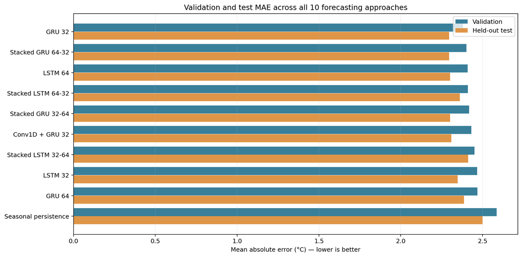

## Learning behavior

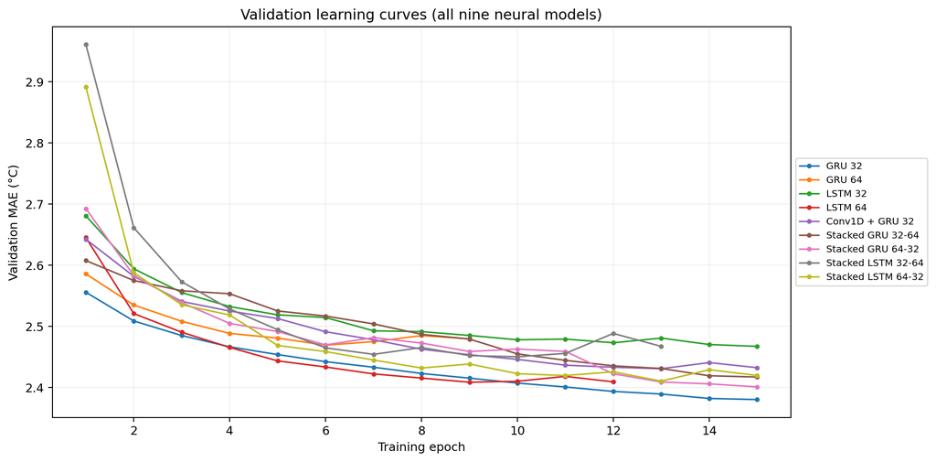

## Example held-out forecasts

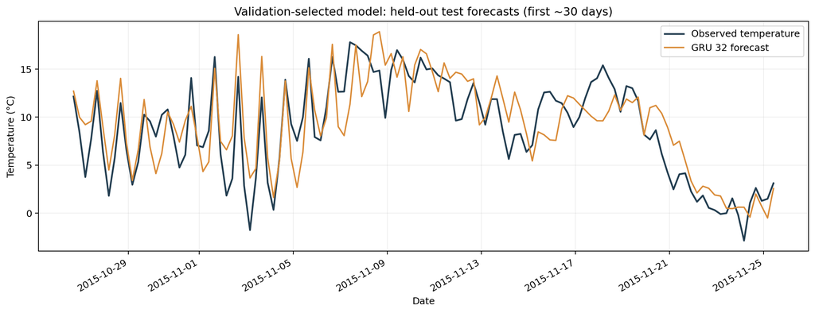

## Results interpretation

64 units raised GRU MAE by 0.089°C versus 32 units. 64 units lowered LSTM MAE by 0.059°C versus 32 units.

Best stacked setup: Stacked GRU 64-32 (2.401°C validation MAE). Best non-stacked recurrent setup: GRU 32 (2.380°C). These results show how changes to recurrent depth and unit order affected this dataset.

## Conclusions and limitations

Both individual recurrent layers and stacked configurations were evaluated, including changing unit counts and their order within two-layer GRU and LSTM models. Model selection used validation error only, and test MAE was reported for every fixed configuration afterward.

This is a single seeded, chronological-split comparison. Neural training has variability, and short training budgets can affect the ranking. Full test results are descriptive: they were not used to revise the validation-selected winner. Results are specific to this weather dataset and setup.

Source: the executed Assignment 3 notebook and exported CSV results.